# DSDA 1995

Data Science and Society using R

Lecture 6 | Data Visualization II

## Plan for Today

- Continue discussing plots in `ggplot`
- Examine Bar graphs
- Examine editing labels and themes
- In class activity

## Plots in R

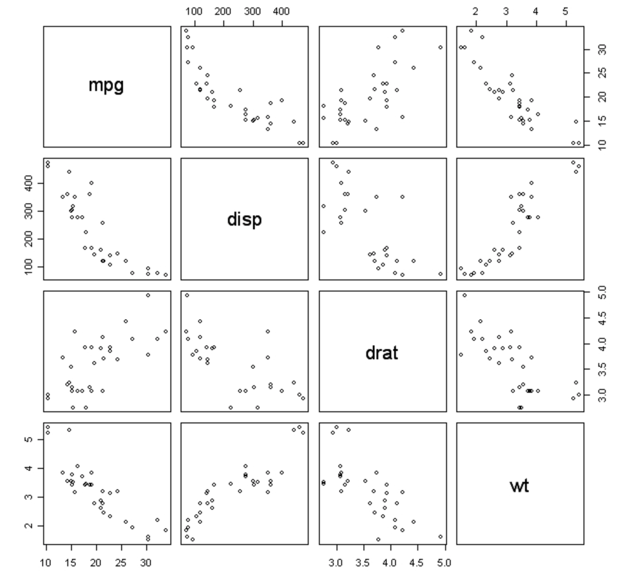

## The Anatomy of ggplot

- Standard:

```r
ggplot(data = <DATA>) +
        <GEOM_FUNCTION>(mapping = aes(<MAPPINGS>))
```

- Recall (again…)
  - `ggplot()` is the plot function
    - Creates a coordinate system that you can add layers to
  - `(Data =)` is where you specify the dataset that you are using
  - `geom_point()` is an added layer, which specifies how the data will be plotted
  - `mapping` defines how variables in your dataset are mapped to visual properties
  - `aes` specify which variables to map to the x and y axes
- Using pipes:

```r
<DATA> %>%
        ggplot() +
        <GEOM_FUNCTION>(mapping = aes(<MAPPINGS>))
```

## Plotting Functions

[figure not shown]

[ggplot Cheatsheet](https://ggplot2.tidyverse.org/index.html#cheatsheet)

## Aesthetics

- Color / Fill / Alpha (transparency)
- Size
- Shape
- Points / Lines / Text

## Faceting

- Faceting creates subplots that each display one subset of the data.
  - useful for categorical variables
- For a single variable, use `facet_wrap(~ <VARIABLE NAME>)`

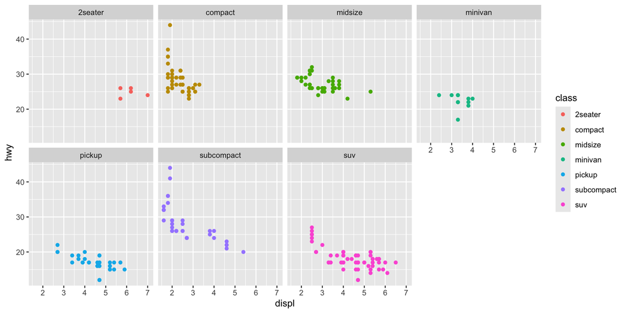

```r
ggplot(data = mpg) +
  geom_point(mapping = aes(x = displ, y = hwy, color = class)) +
  facet_wrap(~ class, nrow = 2)
```

- For a combination of two variables, use `facet_grid( ~ )

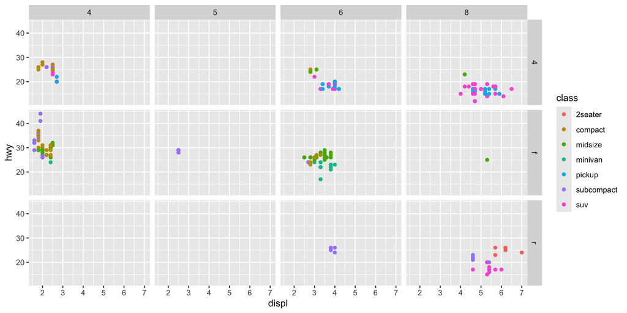

```r
ggplot(data = mpg) +
  geom_point(mapping = aes(x = displ, y = hwy, color = class)) +
  facet_grid(drv ~ cyl)
```

## Geometric Objects

- Geoms
  - A geom is the geometrical object that a plot uses to represent data
  - People often describe plots by the type of geom that the plot uses
  - Every geom function in `ggplot` takes a mapping argument
    - Not every aesthetic works with every geom
      - You could set the shape of a point, but you couldn’t set the “shape” of a line

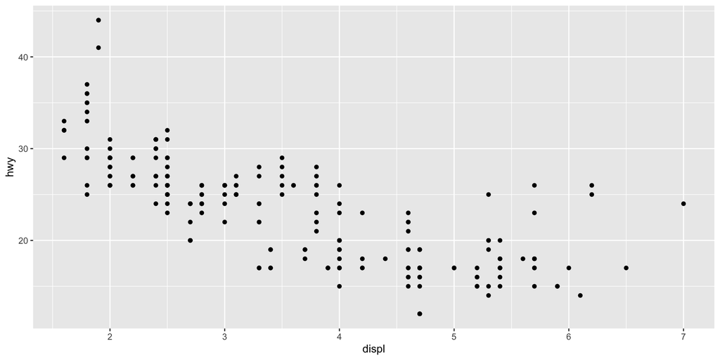

```r
ggplot(data = mpg) +
  geom_point(mapping = aes(x = displ, y = hwy))
```

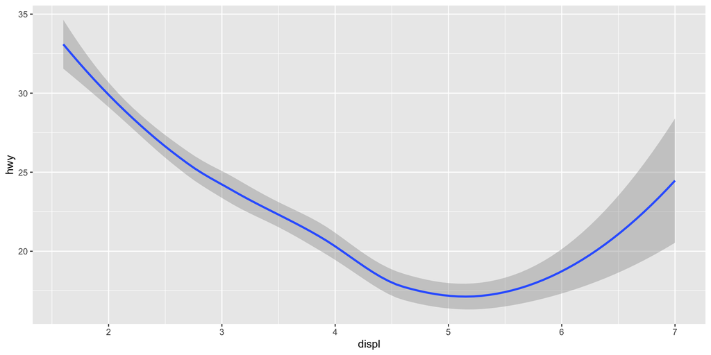

```r
ggplot(data = mpg) +
  geom_smooth(mapping = aes(x = displ, y = hwy))
```

## Multiple Geoms

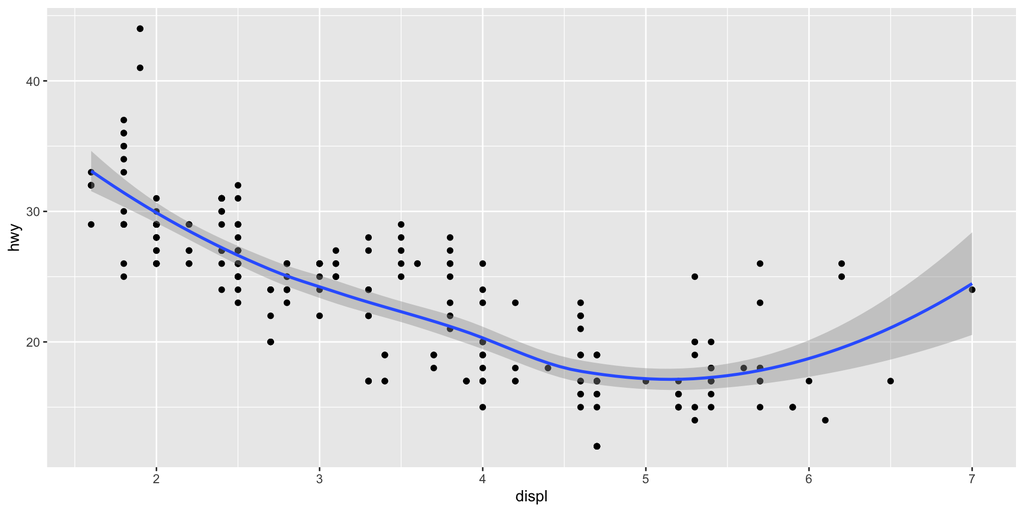

```r
ggplot(data = mpg) +
  geom_point(mapping = aes(x = displ, y = hwy)) +
  geom_smooth(mapping = aes(x = displ, y = hwy))
```

- What do you notice about the code above?
- How could this code be more efficient?

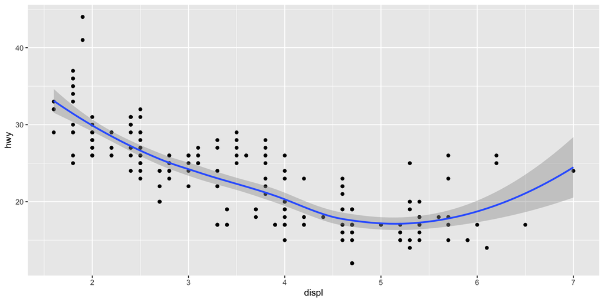

```r
ggplot(data = mpg, mapping = aes(x = displ, y = hwy)) +
  geom_point() +
  geom_smooth()
```

- What is the difference between these two code chunks?
  - Global vs local mapping
  - By passing a set of mappings to `ggplot()`, this will treat the mapping as global and apply to EACH geom
  - By passing a set of mappings to `geom`, this will treat the mapping as local and apply to ONLY that geom

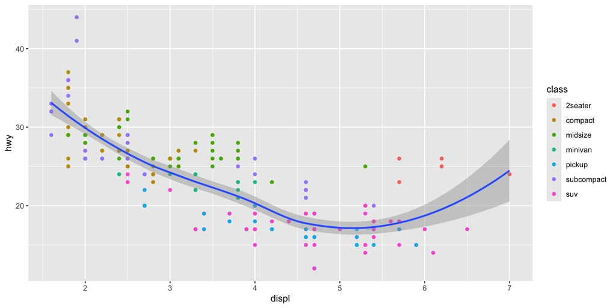

```r
ggplot(data = mpg, mapping = aes(x = displ, y = hwy)) +
  geom_point(mapping = aes(color = class)) +
  geom_smooth()
```

## Other `ggplot` functions

- `coord_flip` flips the x and y axis to improve the readability of plots
- `scales` change the formatting of x and y axes
- `plotly` makes plots interactive; you can hover over points/lines for more information
- `labs` allows you to add/edit a title, subtitle, a caption, and change the x and y axis labels
- `gganimate` allows you to animate plots into gifs

## Barplot

- Bar plots show the relationship between a numeric and categorical variable
- Bar charts, histograms, and frequency polygons bin your data and then plot bin counts

```r
library(tidyverse)

diamonds
```

```
# A tibble: 53,940 × 10
   carat cut       color clarity depth table price     x     y     z
   <dbl> <ord>     <ord> <ord>   <dbl> <dbl> <int> <dbl> <dbl> <dbl>
 1  0.23 Ideal     E     SI2      61.5    55   326  3.95  3.98  2.43
 2  0.21 Premium   E     SI1      59.8    61   326  3.89  3.84  2.31
 3  0.23 Good      E     VS1      56.9    65   327  4.05  4.07  2.31
 4  0.29 Premium   I     VS2      62.4    58   334  4.2   4.23  2.63
 5  0.31 Good      J     SI2      63.3    58   335  4.34  4.35  2.75
 6  0.24 Very Good J     VVS2     62.8    57   336  3.94  3.96  2.48
 7  0.24 Very Good I     VVS1     62.3    57   336  3.95  3.98  2.47
 8  0.26 Very Good H     SI1      61.9    55   337  4.07  4.11  2.53
 9  0.22 Fair      E     VS2      65.1    61   337  3.87  3.78  2.49
10  0.23 Very Good H     VS1      59.4    61   338  4     4.05  2.39
# ℹ 53,930 more rows
```

```r
?diamonds
```

- Let’s build a bar graph that examines the different types of “cut” in the data.

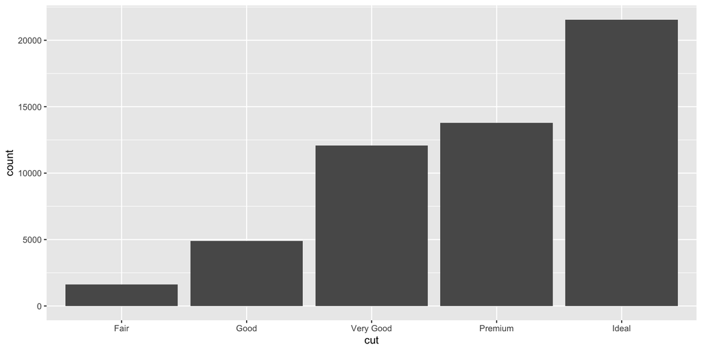

```r
ggplot(data = diamonds) +
  geom_bar(mapping = aes(x = cut))
```

- What do we notice about this plot?
  - Where did “count” come from?

## `stat_count()`

- Many graphs, like scatterplots, plot the raw values of your dataset. Other graphs, like bar charts, calculate new values to plot. How does `ggplot()` compute this?
- `geom_bar()` utilizes `stat_count()` as the default way to make statistical transformations for bar graphs

```r
?geom_bar
```

- You can generally use `geoms` and `stats` interchangeably.
- Every geom has a default stat
- Every stat has a default geom
- This means that you can typically use geoms without worrying about the underlying statistical transformation

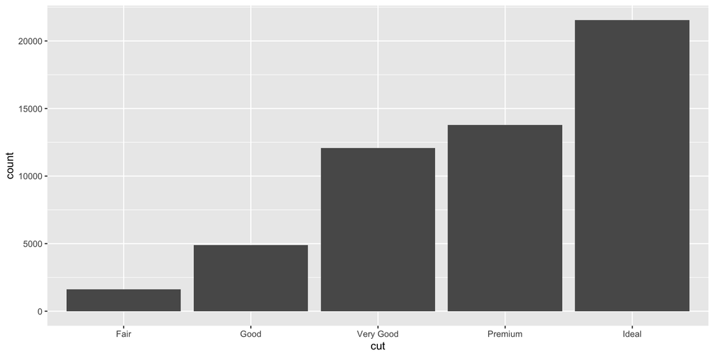

```r
ggplot(data = diamonds) +
  stat_count(mapping = aes(x = cut))
```

- Most of the time, we are not going to be concerned with changing `stat`
- `stat = "identity"`

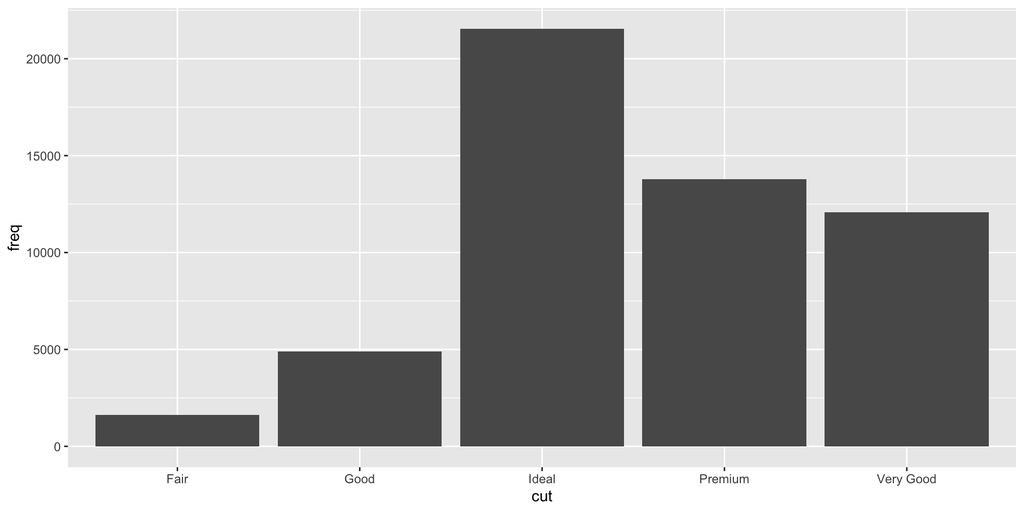

```r
demo <- tribble(
  ~cut,         ~freq,
  "Fair",       1610,
  "Good",       4906,
  "Very Good",  12082,
  "Premium",    13791,
  "Ideal",      21551
)

ggplot(data = demo) +
  geom_bar(mapping = aes(x = cut, y = freq), stat = "identity")
```

- `y = stat(prop), group = 1`

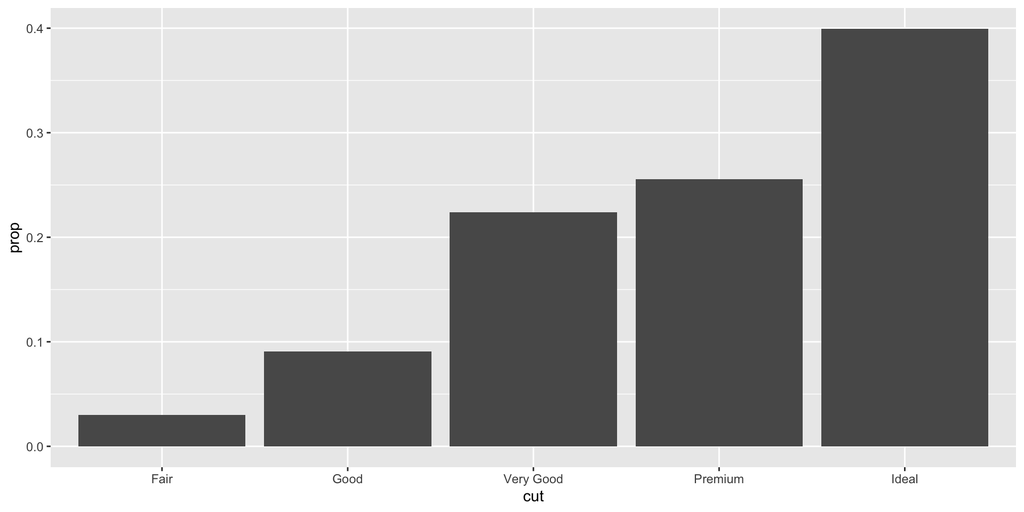

```r
ggplot(data = diamonds) +
  geom_bar(mapping = aes(x = cut, y = stat(prop), group = 1))
```

## Color and Position Adjustments

- **Color**
  - You can use `color =`
  - You can use `fill =`
- Which one is more useful?

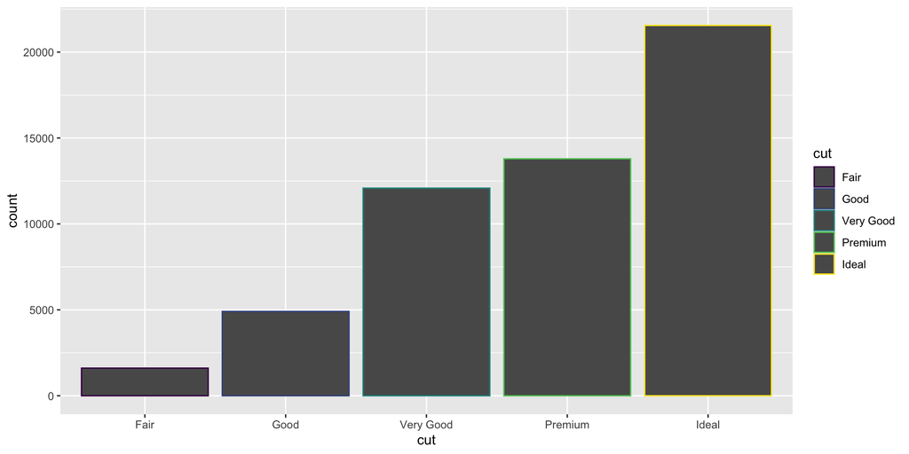

```r
ggplot(data = diamonds) +
  geom_bar(mapping = aes(x = cut, color = cut))
```

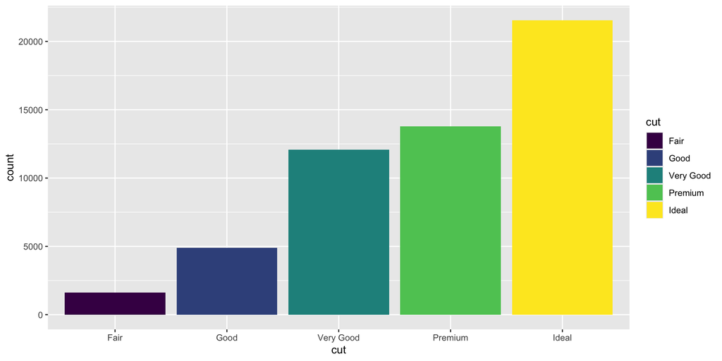

```r
ggplot(data = diamonds) +
  geom_bar(mapping = aes(x = cut, fill = cut))
```

- How does the color aesthetic change if we use the variable “clarity”

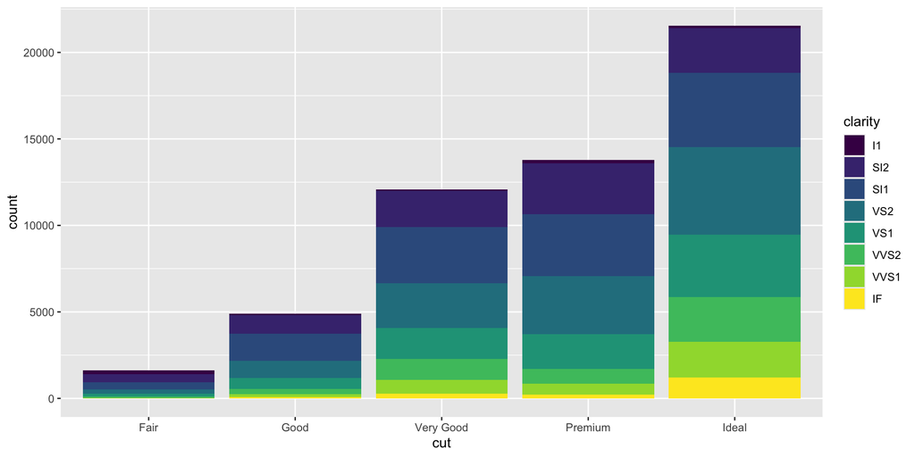

```r
ggplot(data = diamonds) +
  geom_bar(mapping = aes(x = cut, fill = clarity))
```

- **Position**
  - The stacking from the plot above is performed automatically when `position =` is left unchanged
  - If you don’t want a stacked bar chart, you can use one of three other options
    - “identity”
    - “dodge”
    - “fill”
- **Identity**
  - Place each object exactly where it falls in the context of the graph
  - Overlaps the bars
  - Not useful for bar graphs

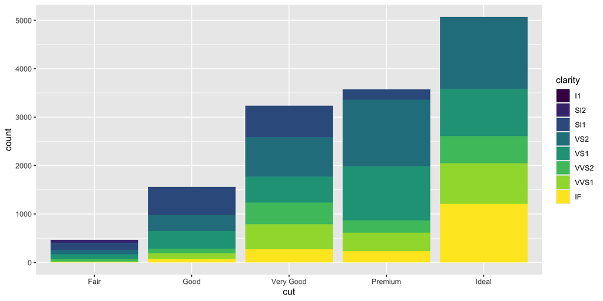

```r
ggplot(data = diamonds, mapping = aes(x = cut, fill = clarity)) +
  geom_bar(position = "identity")
```

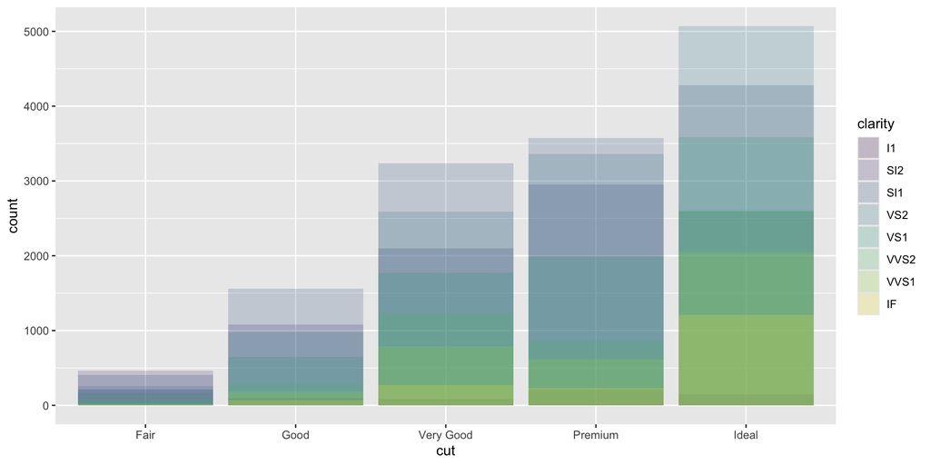

```r
ggplot(data = diamonds, mapping = aes(x = cut, fill = clarity)) +
  geom_bar(alpha = 1/5, position = "identity")
```

- **Fill**
  - Like stacking, but makes each set of stacked bars the same height
  - Easier to compare proportions across groups

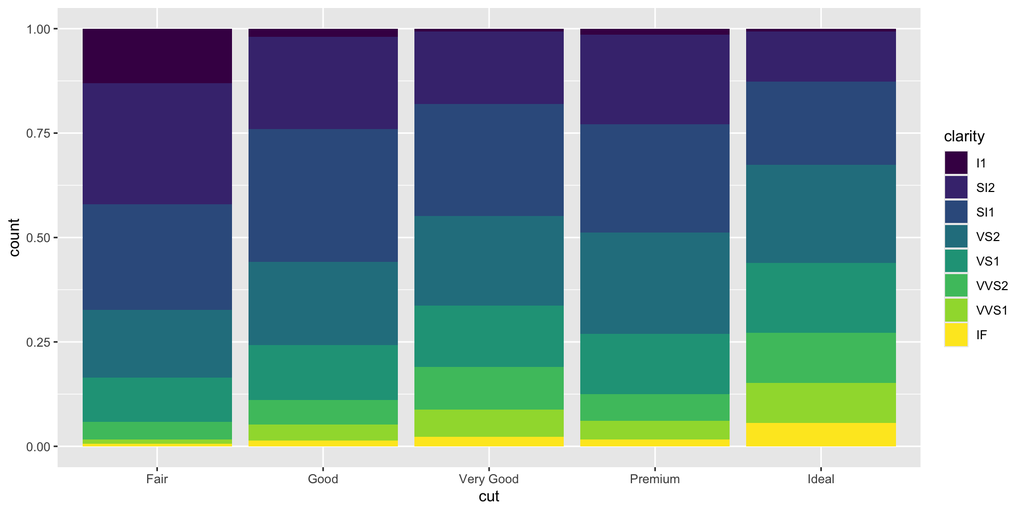

```r
ggplot(data = diamonds) +
  geom_bar(mapping = aes(x = cut, fill = clarity), position = "fill")
```

- **Dodge**
  - Places overlapping objects directly beside one another
  - Easier to compare individual values

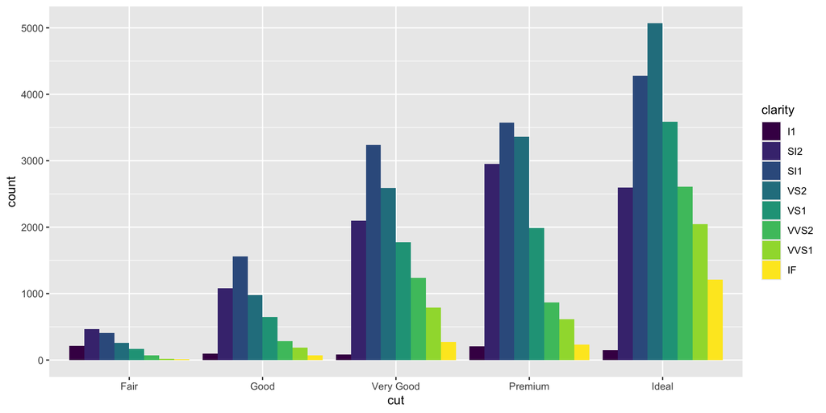

```r
ggplot(data = diamonds) +
  geom_bar(mapping = aes(x = cut, fill = clarity), position = "dodge")
```

## Graphics for Communication

- When exploring data, yourself, you are aware of the data/graph that you have created
- When creating graphs for explanation, you need to ensure that your audience understands the graph

## Labels

- Title
- x - axis
- y - axis

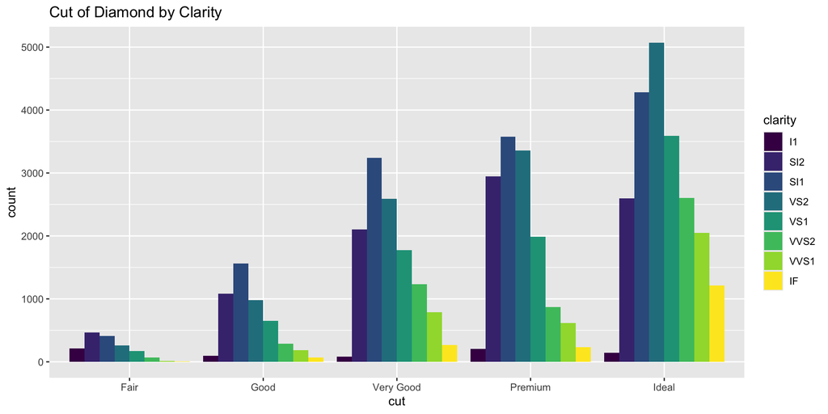

```r
#adding a title
ggplot(data = diamonds) +
  geom_bar(mapping = aes(x = cut, fill = clarity), position = "dodge") +
  labs(title = "Cut of Diamond by Clarity")
```

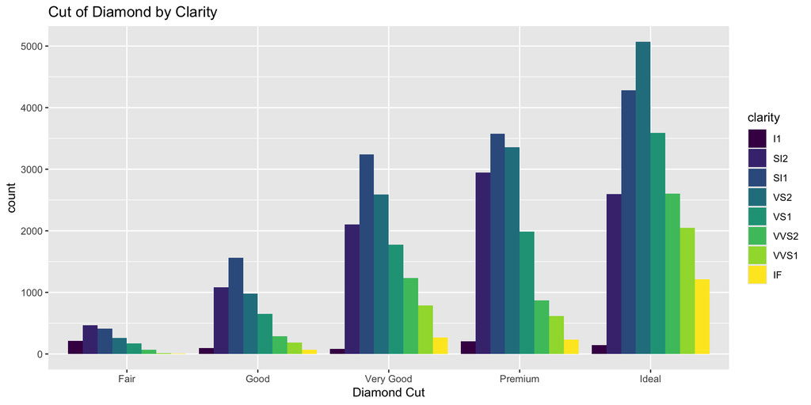

```r
#adding a x-axis
ggplot(data = diamonds) +
  geom_bar(mapping = aes(x = cut, fill = clarity), position = "dodge") +
  labs(title = "Cut of Diamond by Clarity",
       x = "Diamond Cut")
```

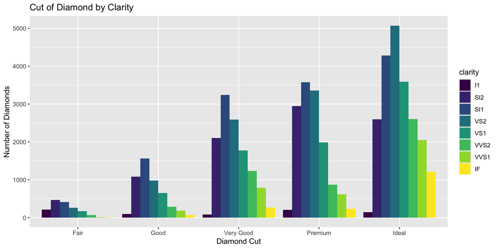

```r
#adding a y-axis
ggplot(data = diamonds) +
  geom_bar(mapping = aes(x = cut, fill = clarity), position = "dodge") +
  labs(title = "Cut of Diamond by Clarity",
       x = "Diamond Cut",
       y = "Number of Diamonds")
```

## Scales

- Adjusting the scales allows you to control the range of the x and y-axis
- ``ggplot()` automatically adds default scales behind the scenes

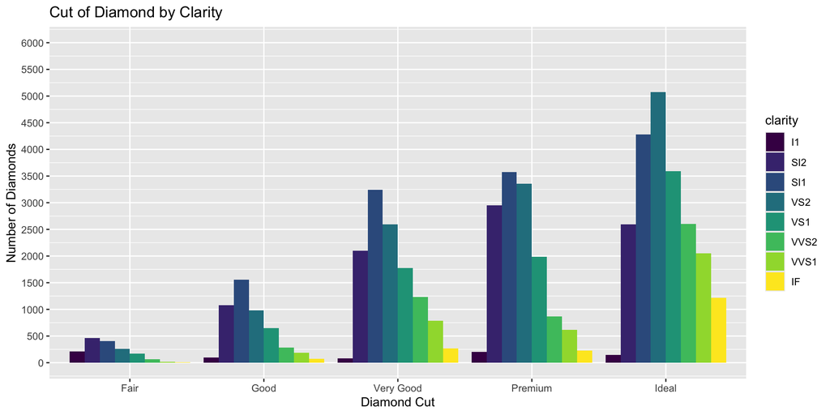

```r
#change y-axis scale
ggplot(data = diamonds) +
  geom_bar(mapping = aes(x = cut, fill = clarity), position = "dodge") +
  labs(title = "Cut of Diamond by Clarity",
       x = "Diamond Cut",
       y = "Number of Diamonds") +
  scale_y_continuous(breaks = seq(0, 6000, by = 500), limits = c(0, 6000))
```

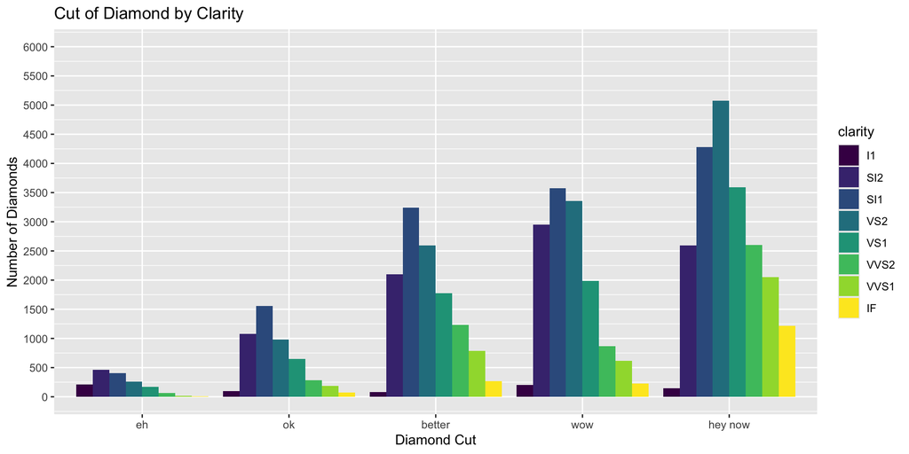

```r
#change x-axis scale (labels)
ggplot(data = diamonds) +
  geom_bar(mapping = aes(x = cut, fill = clarity), position = "dodge") +
  labs(title = "Cut of Diamond by Clarity",
       x = "Diamond Cut",
       y = "Number of Diamonds") +
  scale_y_continuous(breaks = seq(0, 6000, by = 500), limits = c(0, 6000)) +
  scale_x_discrete(labels = c("eh", "ok", "better", "wow", "hey now"))
```

## Themes

- Default theme has a grey background
- Not the most visually pleasing

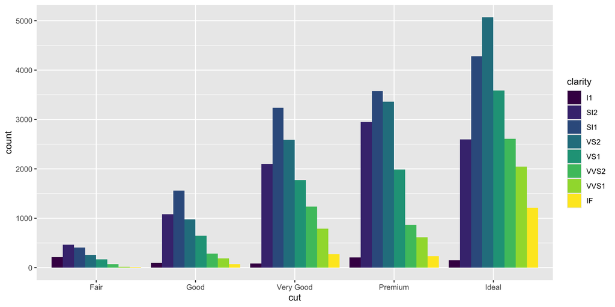

```r
#default theme
ggplot(data = diamonds) +
  geom_bar(mapping = aes(x = cut, fill = clarity), position = "dodge")
```

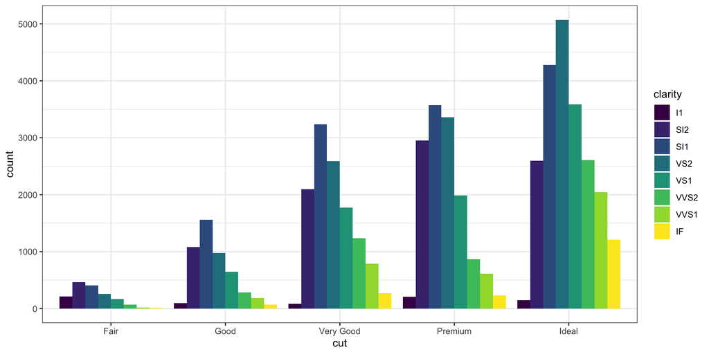

```r
#theme_bw()
ggplot(data = diamonds) +
  geom_bar(mapping = aes(x = cut, fill = clarity), position = "dodge") +
  theme_bw()
```

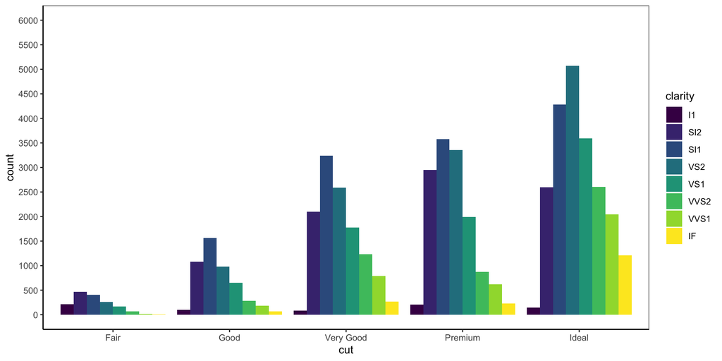

```r
#theme_bw() with grid removed
ggplot(data = diamonds) +
  geom_bar(mapping = aes(x = cut, fill = clarity), position = "dodge") +
  scale_y_continuous(breaks = seq(0, 6000, by = 500), limits = c(0, 6000)) +
  theme_bw() +
  theme(axis.line = element_line(color='black'),
    plot.background = element_blank(),
    panel.grid.minor = element_blank(),
    panel.grid.major = element_blank())
```

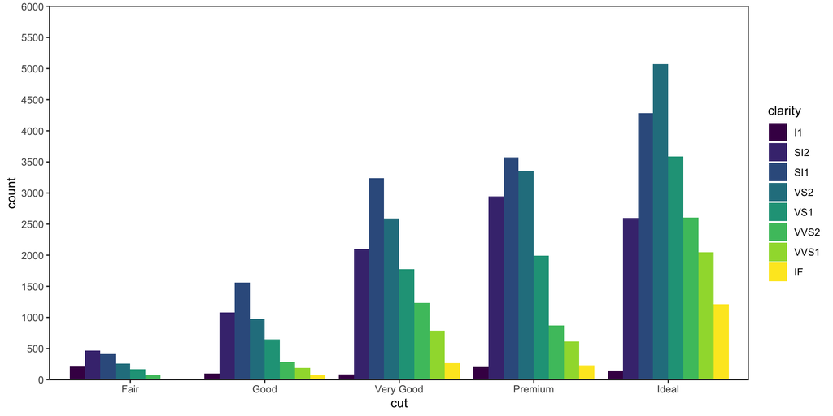

```r
#theme_bw() with origin at 0,0
ggplot(data = diamonds) +
  geom_bar(mapping = aes(x = cut, fill = clarity), position = "dodge") +
  scale_y_continuous(breaks = seq(0, 6000, by = 500), limits = c(0, 6000), expand = c(0,0)) +
  theme_bw() +
  theme(axis.line = element_line(color='black'),
    plot.background = element_blank(),
    panel.grid.minor = element_blank(),
    panel.grid.major = element_blank())
```

## In-Class Activity

- We are going to practice producing and altering `ggplot()`
- Get with a partner and work through Week 3 | Class Activity

## For Next Class

- Review what you learned today
- Do new set of readings:
  - We are going to discuss how we transform data in R with Tidyverse
  - R4DS Chapter 3
    - Follow along the exercises with your own computer
- Bring your laptops to class